# Name: Sayed Ebrahim Mustafa Alawi

> This dataset is from kaggle and it is a dataset about the applications available on the google app store.

# Univariate Plots Section

```
##                                                  App       Category Rating
## 1     Photo Editor & Candy Camera & Grid & ScrapBook ART_AND_DESIGN    4.1
## 2                                Coloring book moana ART_AND_DESIGN    3.9
## 3 U Launcher Lite – FREE Live Cool Themes, Hide Apps ART_AND_DESIGN    4.7
## 4                              Sketch - Draw & Paint ART_AND_DESIGN    4.5
## 5              Pixel Draw - Number Art Coloring Book ART_AND_DESIGN    4.3
## 6                         Paper flowers instructions ART_AND_DESIGN    4.4
##   Reviews Size    Installs Type Price Content.Rating
## 1     159  19M     10,000+ Free     0       Everyone
## 2     967  14M    500,000+ Free     0       Everyone
## 3   87510 8.7M  5,000,000+ Free     0       Everyone
## 4  215644  25M 50,000,000+ Free     0           Teen
## 5     967 2.8M    100,000+ Free     0       Everyone
## 6     167 5.6M     50,000+ Free     0       Everyone
##                      Genres     Last.Updated        Current.Ver
## 1              Art & Design  January 7, 2018              1.0.0
## 2 Art & Design;Pretend Play January 15, 2018              2.0.0
## 3              Art & Design   August 1, 2018              1.2.4
## 4              Art & Design     June 8, 2018 Varies with device
## 5   Art & Design;Creativity    June 20, 2018                1.1
## 6              Art & Design   March 26, 2017                1.0
##    Android.Ver
## 1 4.0.3 and up
## 2 4.0.3 and up
## 3 4.0.3 and up
## 4   4.2 and up
## 5   4.4 and up
## 6   2.3 and up
```

```
## [1] 10841    13
```

```
##                                                 App
##  ROBLOX                                           :    9
##  CBS Sports App - Scores, News, Stats & Watch Live:    8
##  8 Ball Pool                                      :    7
##  Candy Crush Saga                                 :    7
##  Duolingo: Learn Languages Free                   :    7
##  ESPN                                             :    7
##  (Other)                                          :10796
##          Category        Rating          Reviews
##  FAMILY      :1972   Min.   : 1.000   0      : 596
##  GAME        :1144   1st Qu.: 4.000   1      : 272
##  TOOLS       : 843   Median : 4.300   2      : 214
##  MEDICAL     : 463   Mean   : 4.193   3      : 175
##  BUSINESS    : 460   3rd Qu.: 4.500   4      : 137
##  PRODUCTIVITY: 424   Max.   :19.000   5      : 108
##  (Other)     :5535   NA's   :1474     (Other):9339
##                  Size             Installs      Type           Price
##  Varies with device:1695   1,000,000+ :1579   0   :    1   0      :10040
##  11M               : 198   10,000,000+:1252   Free:10039   $0.99  :  148
##  12M               : 196   100,000+   :1169   NaN :    1   $2.99  :  129
##  14M               : 194   10,000+    :1054   Paid:  800   $1.99  :   73
##  13M               : 191   1,000+     : 907                $4.99  :   72
##  15M               : 184   5,000,000+ : 752                $3.99  :   63
##  (Other)           :8183   (Other)    :4128                (Other):  316
##          Content.Rating           Genres             Last.Updated
##                 :   1   Tools        : 842   August 3, 2018: 326
##  Adults only 18+:   3   Entertainment: 623   August 2, 2018: 304
##  Everyone       :8714   Education    : 549   July 31, 2018 : 294
##  Everyone 10+   : 414   Medical      : 463   August 1, 2018: 285
##  Mature 17+     : 499   Business     : 460   July 30, 2018 : 211
##  Teen           :1208   Productivity : 424   July 25, 2018 : 164
##  Unrated        :   2   (Other)      :7480   (Other)       :9257
##              Current.Ver               Android.Ver
##  Varies with device:1459   4.1 and up        :2451
##  1.0               : 809   4.0.3 and up      :1501
##  1.1               : 264   4.0 and up        :1375
##  1.2               : 178   Varies with device:1362
##  2.0               : 151   4.4 and up        : 980
##  1.3               : 145   2.3 and up        : 652
##  (Other)           :7835   (Other)           :2520
```

> In this dataset there are 10841 observation and 13 variables.

### Categories

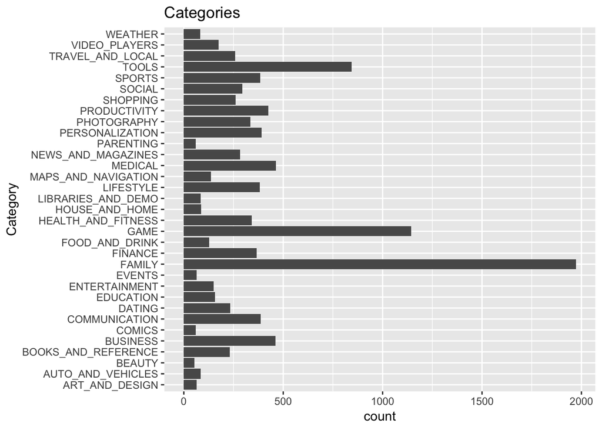

### Installs

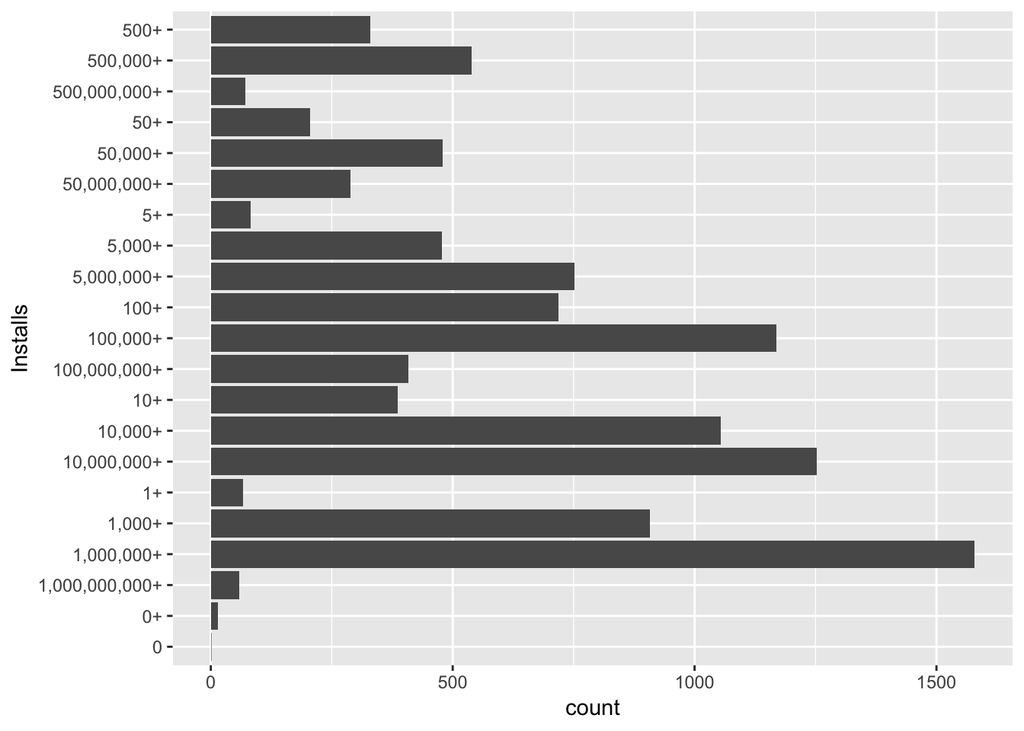

### Rating

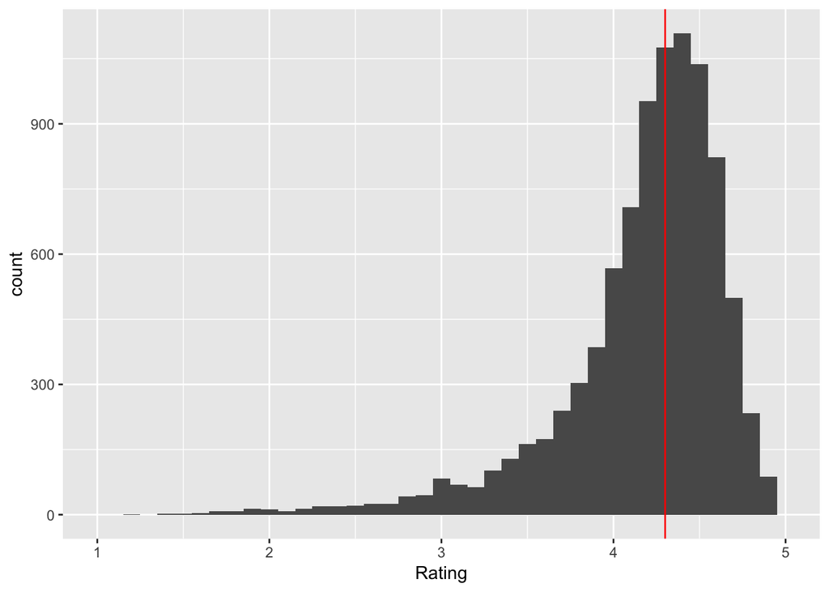

```
##    Min. 1st Qu.  Median    Mean 3rd Qu.    Max.    NA's
##   1.000   4.000   4.300   4.192   4.500   5.000    1474
```

> The ratings of the apps on the app store follows a left skewed distribution. most apps are rated above 4.0 and about half are rated between 4.3 and 5.

### Genres

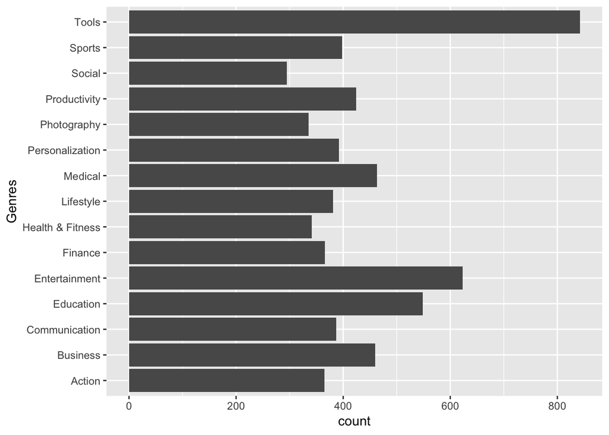

### Type

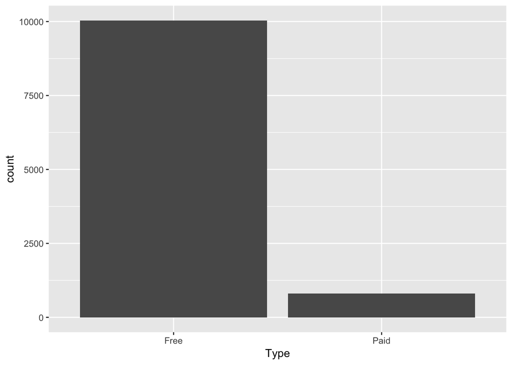

> There are a lot more free apps in the app store than paid apps. But we need to keep in mind that some of these free apps have in app purchases or they are free to download but not to use.

### Content Rating

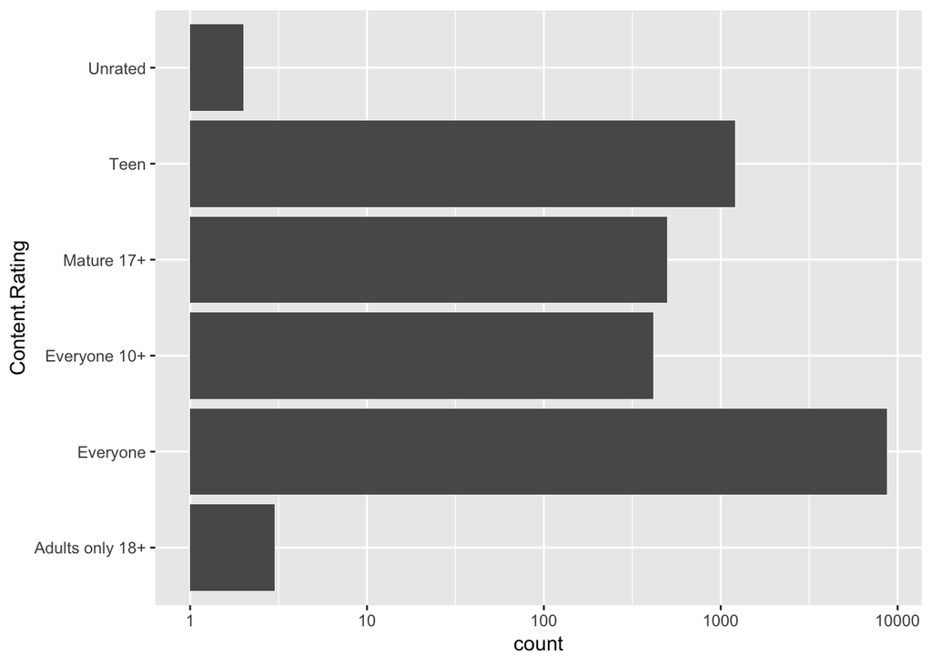

> Most apps are suitable for people under the age of 18, with the apps that have an E rating more than all the other categories combined.

### Reviews

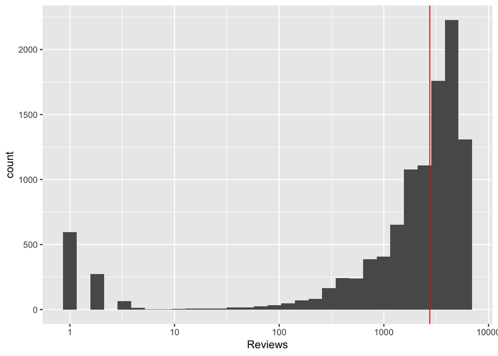

### Size

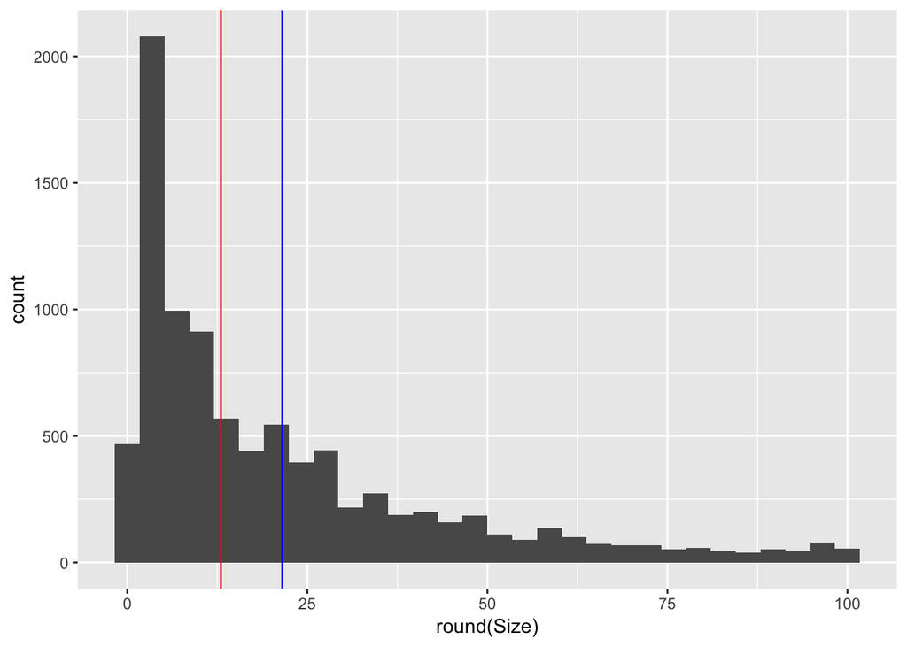

[output not shown]

```
##     Min.  1st Qu.   Median     Mean  3rd Qu.     Max.
##   0.0083   4.9000  13.0000  21.5162  30.0000 100.0000
```

### Price

```
##    Min. 1st Qu.  Median    Mean 3rd Qu.    Max.
##    0.99    1.49    2.99   13.92    4.99  400.00
```

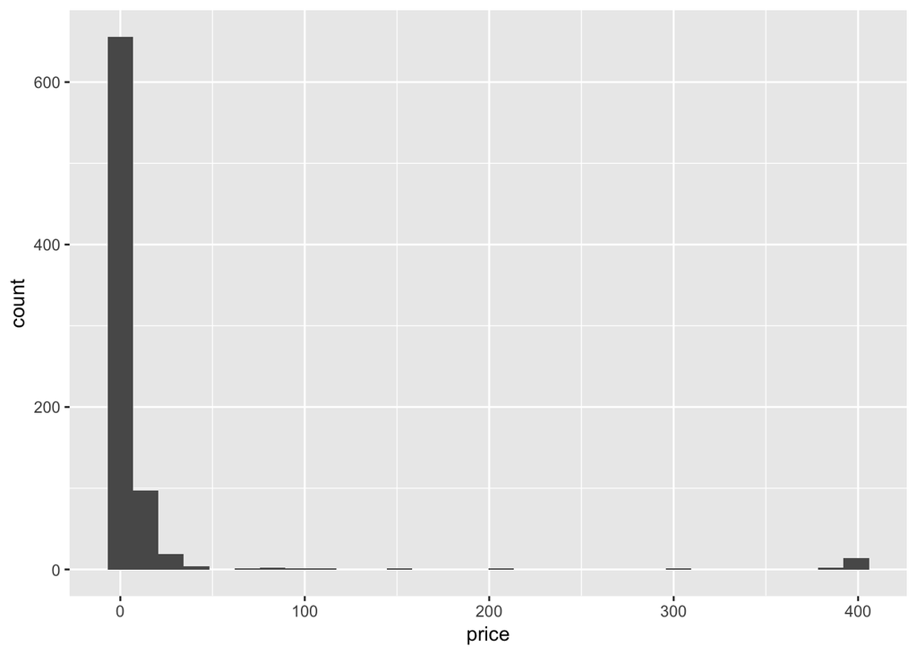

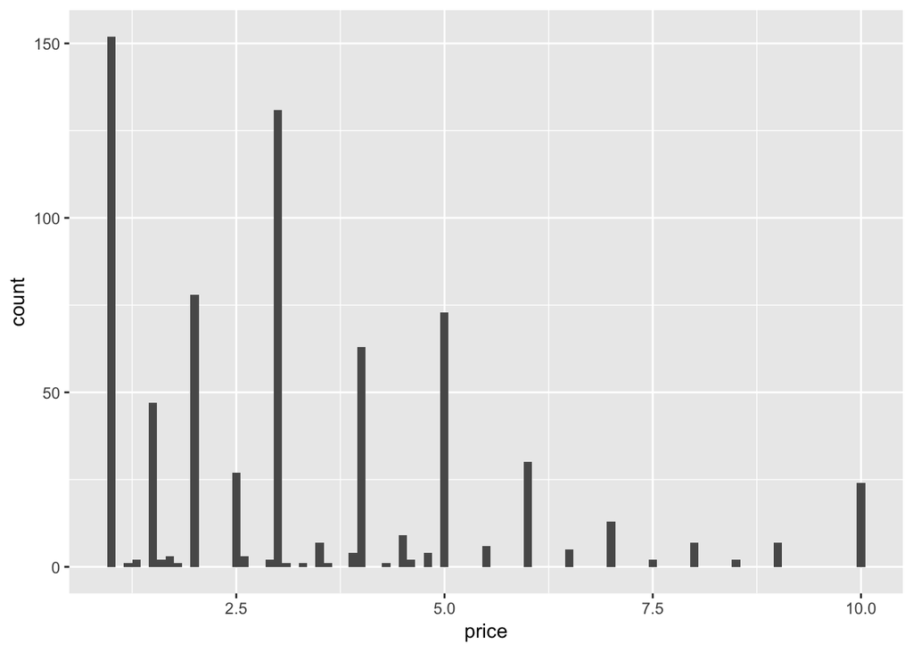

> Most apps are under 10$ with some prices point being more frequent than others; (0.99,1.99 etc.)

# Univariate Analysis

### What is the structure of your dataset?

> In this dataset there is infortmation about 10841 apps that are available in the google app store and 13 columns.

> About some of the columns:

> Type - Free or paid

> Categories - There are 33 different Categories (once you remove 1.9)

> Installs- There are 21 different levels for installs that tell us how many times the app has been installed. The levels are not evenly spaced. (once you remove free)

> Rating - The apps can be rated from 1-5

> Genres - There are 120 different Genres

> Content.Rating - An application can be given 5 different content rating; Teen, Mature 17+, Everyone 10+, Everyone, Adults only 18+. Some of the applications are not rated

> The columns in our dataset - Category, Installs, Type, Content.Rating, Genres, current.ver, Android.ver., last.updated, Apps ,Rating, Reviews, size and price.

### What is/are the main feature(s) of interest in your dataset?

> Rating is my main feature of interest in this dataset. I would like to see how the different features affect the rating.

### What other features in the dataset do you think will help support your investigation into your feature(s) of interest?

> I suspect that Genres, Category, Type, and Price affect the rating,

### Did you create any new variables from existing variables in the dataset?

> I have, only to use them temporarily to show a cleaner more relevant plot.

### Of the features you investigated, were there any unusual distributions? Did you perform any operations on the data to tidy, adjust, or change the form of the data? If so, why did you do this?

# Bivariate Plots Section

# Rating

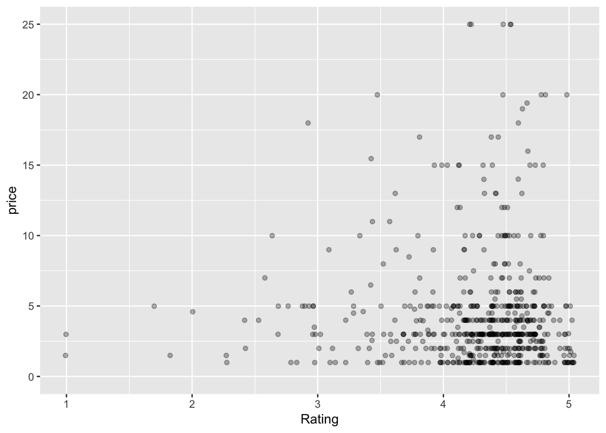

```
##    Min. 1st Qu.  Median    Mean 3rd Qu.    Max.    NA's
##   1.000   4.100   4.400   4.267   4.600   5.000     153
```

> Rating statistics for free apps

```
##    Min. 1st Qu.  Median    Mean 3rd Qu.    Max.    NA's
##   1.000   4.000   4.300   4.186   4.500   5.000    1320
```

> Paid apps are slightly better rated than free apps.

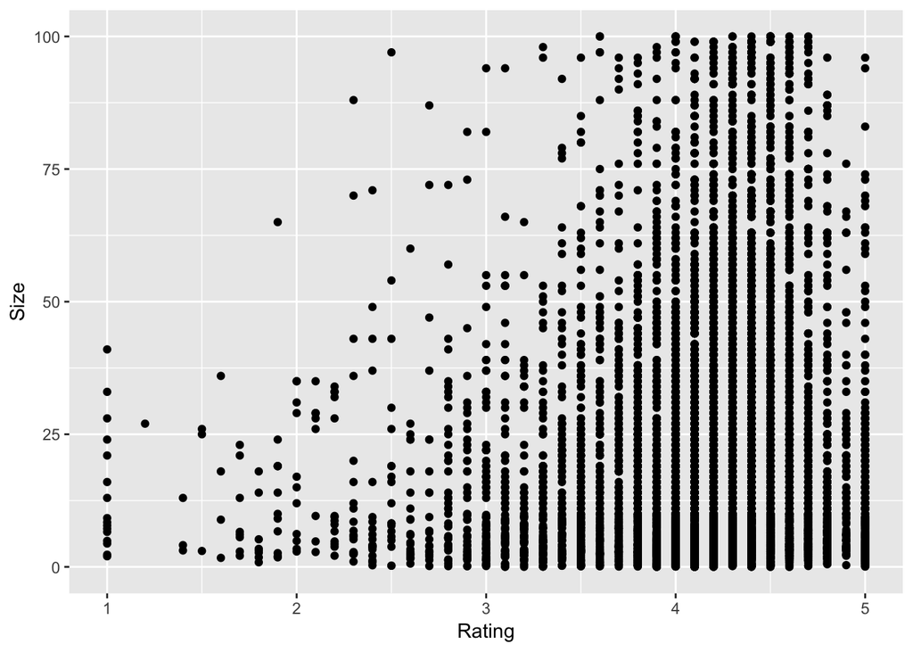

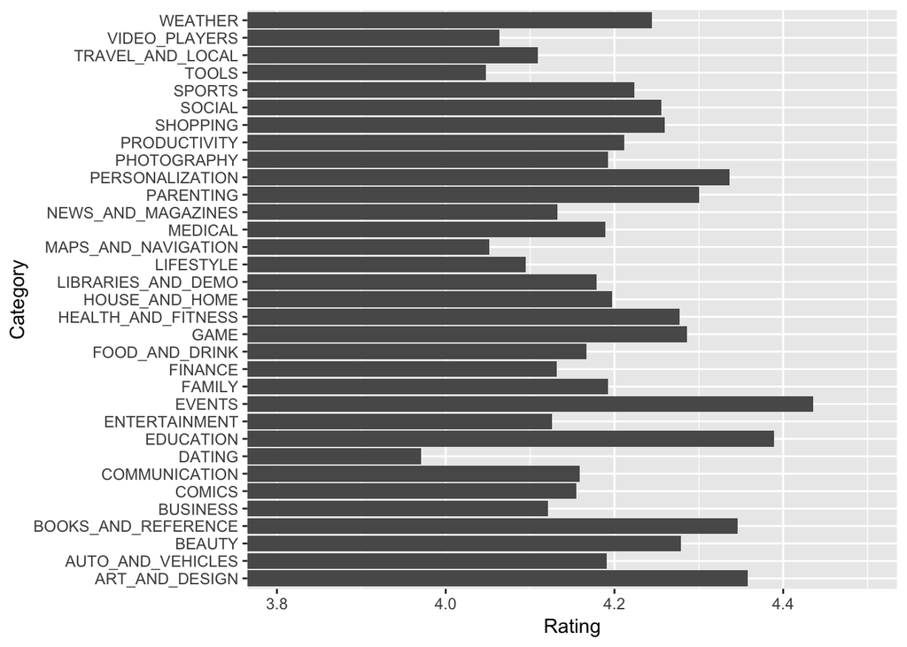

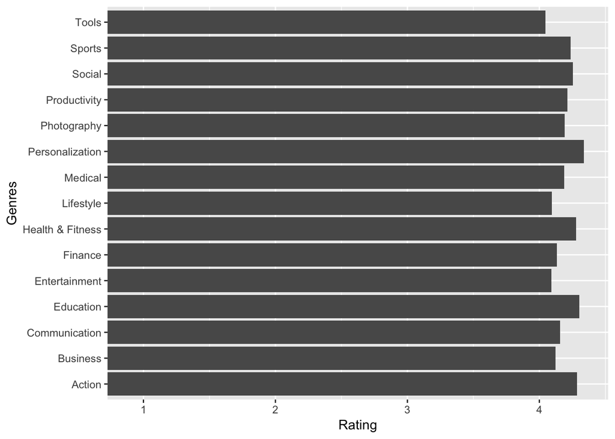

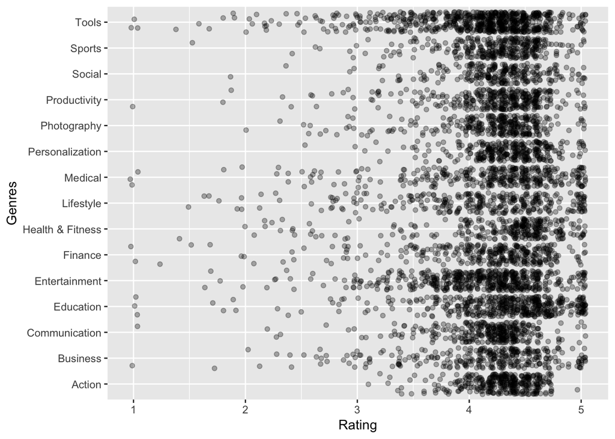

> When we look at the most popular genres we find that personalization is on averahe the best rated genre followed by education.

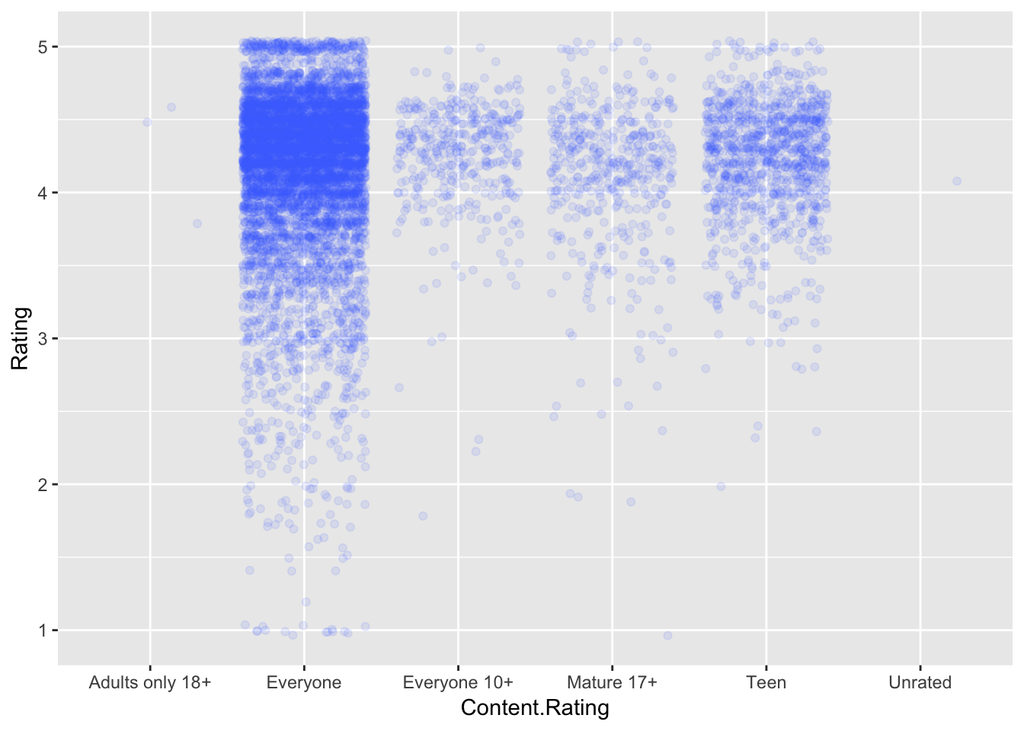

# Price

## Price and Category

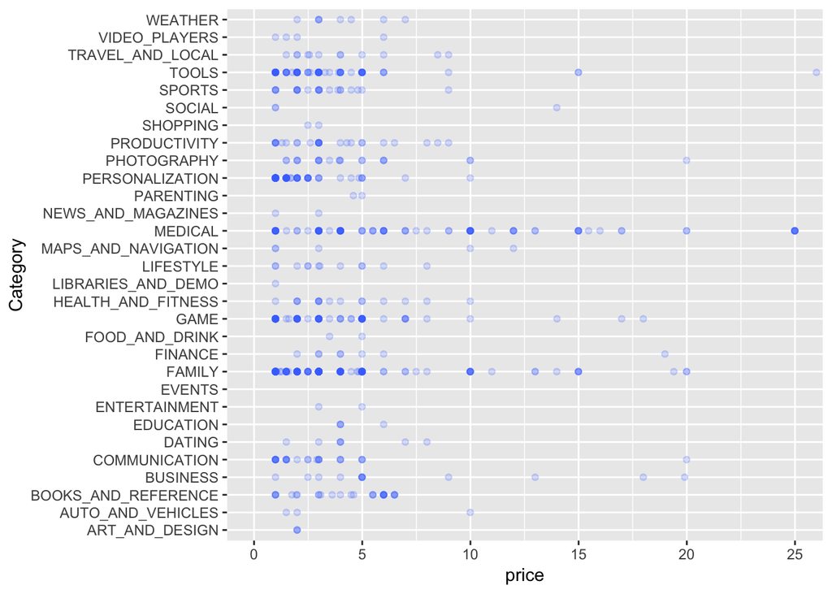

```r
paidapp = subset(df, Type == 'Paid')

ggplot(aes(x =Category , y =price ), data = paidapp)+
  geom_point(alpha = 0.2, color = 'royalblue1')+
  coord_flip(ylim = c(0, quantile(paidapp$price,0.95)))
```

# Bivariate Analysis

### Talk about some of the relationships you observed in this part of the investigation. How did the feature(s) of interest vary with other features in the dataset?

### Did you observe any interesting relationships between the other features (not the main feature(s) of interest)?

### What was the strongest relationship you found?

# Multivariate Plots Section

# Multivariate Analysis

### Talk about some of the relationships you observed in this part of the investigation. Were there features that strengthened each other in terms of looking at your feature(s) of interest?

### Were there any interesting or surprising interactions between features?

### OPTIONAL: Did you create any models with your dataset? Discuss the strengths and limitations of your model.

# Final Plots and Summary

### Plot One

### Description One

### Plot Two

### Description Two

### Plot Three

### Description Three

# Reflection